# Association between cholesterol ration and health indicators

Shengxuan Wang

December 10, 2018

# 1 Introduction

In this study, I would like to study the association between cholesterol ratio and many health indicators, including BMI(body mass index), SBP(systolic blood pressure), DBP(Diastolic blood pressure), FPG(fasting plasma glucose), drinking and smoking status. Data were extracted from a computerized database established by the Rich Healthcare Group in China, which includes all medical records for participants who received a health check from 2010 to 2016.

# 2 Initial Setup and Data Load

## 2.1 Initial Setup and Package Loads in R

```r
source("Love-boost.R")

library(knitr); library(rmdformats); library(magrittr)
library(skimr); library(Hmisc); library(Epi); library(vcd)
library(simputation); library(GGally); library(car)
library(broom); library(tidyverse)

options(max.print="75")
opts_chunk$set(comment=NA,
               message=FALSE,
               warning=FALSE)
opts_knit$set(width=75)

skimr::skim_with(numeric = list(hist = NULL),
                 integer = list(hist = NULL))
```

## 2.2 Load the raw data into R

Here I load the raw data into R, and convert character variables to factors.

```r
RChealthdata <- read_csv("RChealthdata2.csv") %>%
  mutate_if(is.character, as.factor) %>%
  tbl_df
RChealthdata
```

```
# A tibble: 211,833 x 25
      id   Age `Gender(1, male…  site `height(cm)` `weight(kg)`   bmi   sbp
   <int> <int>            <int> <int>        <dbl>        <dbl> <dbl> <int>
 1     1    43                2    16         166.         53.5  19.3    96
 2     2    34                1     2         169          57    20     124
 3     3    32                2     2         157          51    20.7    98
 4    11    59                1     2         165          63    23.1   136
 5    14    30                2     9         164.         48.5  18.1   107
 6    19    41                2     5         157          57.9  23.5   119
 7    25    51                2    14         170          61.8  21.4   123
 8    26    36                1    14         166          66.7  24.2   111
 9    27    31                1     7         167          61.5  22.1   130
10    34    31                1     3         162.         58.5  22.4   104
# ... with 211,823 more rows, and 17 more variables: dbp <int>, fpg <dbl>,
#   cholesterol <dbl>, `Triglyceride(mmol/L)` <dbl>, HDL <dbl>, LDL <dbl>,
#   `ALT(U/L)` <dbl>, `AST(U/L)` <dbl>, `BUN(mmol/L)` <dbl>,
#   `CCR(umol/L)` <dbl>, fpg2 <dbl>, `Diabetes diagnosed during
#   followup_1,Yes_` <int>, diabetes <int>, `year of followup` <dbl>,
#   smoking_status <int>, drinking_status <int>, family_histroy <int>
```

# 3 Building a Tidy Data Set

## 3.1 Select variables that will be included in the new dataset

I select these 9 variables in my study. For predictors, I use `Age`,`bmi`, `sbp`, `dbp`, `fpg2`, `smoking_status`, `drinking_status`. For outcome, I will use ‘cholesterol’ and ‘HDL’ to calculate the outcome in my study.

```r
RCdata <- select(RChealthdata, id, Age, bmi, sbp, dbp, fpg2,
                 cholesterol, HDL, smoking_status, drinking_status)
RCdata
```

```
# A tibble: 211,833 x 10
      id   Age   bmi   sbp   dbp  fpg2 cholesterol   HDL smoking_status
   <int> <int> <dbl> <int> <int> <dbl>       <dbl> <dbl>          <int>
 1     1    43  19.3    96    57  4.97        5.13 NA                 3
 2     2    34  20     124    69  5.5         4.61  1.09             NA
 3     3    32  20.7    98    68  4.9         4.73 NA                NA
 4    11    59  23.1   136    73  5.5         4.5   1.53              3
 5    14    30  18.1   107    76  4.82        3.48  1.55             NA
 6    19    41  23.5   119    83  5           3.7  NA                NA
 7    25    51  21.4   123    66  4.8         4.77 NA                NA
 8    26    36  24.2   111    67  5.32        4.75  1.2              NA
 9    27    31  22.1   130    61  4.8         3.93  1.26             NA
10    34    31  22.4   104    74  5.1         4.48 NA                 3
# ... with 211,823 more rows, and 1 more variable: drinking_status <int>
```

## 3.2 Calculating the `cho_ratio` outcome

The `cho_ratio` outcome is measured by dividing the total `cholesterol` by the `HDL`.

```r
RCdata <- RCdata %>%
  mutate(HDL_rc=ifelse(HDL==0,NA,HDL),
         cho_ratio = cholesterol/HDL_rc)

RCdata
```

```
# A tibble: 211,833 x 12
      id   Age   bmi   sbp   dbp  fpg2 cholesterol   HDL smoking_status
   <int> <int> <dbl> <int> <int> <dbl>       <dbl> <dbl>          <int>
 1     1    43  19.3    96    57  4.97        5.13 NA                 3
 2     2    34  20     124    69  5.5         4.61  1.09             NA
 3     3    32  20.7    98    68  4.9         4.73 NA                NA
 4    11    59  23.1   136    73  5.5         4.5   1.53              3
 5    14    30  18.1   107    76  4.82        3.48  1.55             NA
 6    19    41  23.5   119    83  5           3.7  NA                NA
 7    25    51  21.4   123    66  4.8         4.77 NA                NA
 8    26    36  24.2   111    67  5.32        4.75  1.2              NA
 9    27    31  22.1   130    61  4.8         3.93  1.26             NA
10    34    31  22.4   104    74  5.1         4.48 NA                 3
# ... with 211,823 more rows, and 3 more variables: drinking_status <int>,
#   HDL_rc <dbl>, cho_ratio <dbl>
```

## 3.3 Relabeling the levels of `smoking_status` and `drinking_status`

For `smoking_status` and `drinking_status`, I convert the level from “1,2,3” to “current, past, never”. This is more clear in the future study.

```r
RCdata$smoking_status = as.factor(RCdata$smoking_status)
RCdata$drinking_status = as.factor(RCdata$drinking_status)

RCdata <-RCdata %>%
mutate(smoke_sta = fct_recode(smoking_status,
                        "current"  = "1",
                        "past" = "2",
                        "never" = "3"))
RCdata <- RCdata %>%
mutate(drink_sta = fct_recode(drinking_status,
                             "current"  = "1",
                        "past" = "2",
                        "never" = "3" ))
RCdata
```

```
# A tibble: 211,833 x 14
      id   Age   bmi   sbp   dbp  fpg2 cholesterol   HDL smoking_status
   <int> <int> <dbl> <int> <int> <dbl>       <dbl> <dbl> <fct>
 1     1    43  19.3    96    57  4.97        5.13 NA    3
 2     2    34  20     124    69  5.5         4.61  1.09 <NA>
 3     3    32  20.7    98    68  4.9         4.73 NA    <NA>
 4    11    59  23.1   136    73  5.5         4.5   1.53 3
 5    14    30  18.1   107    76  4.82        3.48  1.55 <NA>
 6    19    41  23.5   119    83  5           3.7  NA    <NA>
 7    25    51  21.4   123    66  4.8         4.77 NA    <NA>
 8    26    36  24.2   111    67  5.32        4.75  1.2  <NA>
 9    27    31  22.1   130    61  4.8         3.93  1.26 <NA>
10    34    31  22.4   104    74  5.1         4.48 NA    3
# ... with 211,823 more rows, and 5 more variables: drinking_status <fct>,
#   HDL_rc <dbl>, cho_ratio <dbl>, smoke_sta <fct>, drink_sta <fct>
```

## 3.4 Check the categorical variables

Each variable have three levels and some missing values, I will deal with the missing value later. To be noticed, these two variables have same numbers of missing values, so I assume that there were same people that didn’t respond these two questions. But I will figure this out in the future analysis.

```r
RCdata %>% count(smoke_sta)
```

```
# A tibble: 4 x 2
  smoke_sta      n
  <fct>      <int>
1 current    12075
2 past        2559
3 never      45596
4 <NA>      151603
```

```r
RCdata %>% count(drink_sta)
```

```
# A tibble: 4 x 2
  drink_sta      n
  <fct>      <int>
1 current     1351
2 past        8956
3 never      49923
4 <NA>      151603
```

## 3.5 Filter people that are younger than 60 years old

I exclude people that are over 60 years old because older population usually have higher cholesterol levels comparing to other age groups. Include those older people may affect the model, so I exclude them.

```r
RCdata <- RCdata %>%
  filter(Age < 60)
RCdata
```

```
# A tibble: 187,029 x 14
      id   Age   bmi   sbp   dbp  fpg2 cholesterol   HDL smoking_status
   <int> <int> <dbl> <int> <int> <dbl>       <dbl> <dbl> <fct>
 1     1    43  19.3    96    57  4.97        5.13 NA    3
 2     2    34  20     124    69  5.5         4.61  1.09 <NA>
 3     3    32  20.7    98    68  4.9         4.73 NA    <NA>
 4    11    59  23.1   136    73  5.5         4.5   1.53 3
 5    14    30  18.1   107    76  4.82        3.48  1.55 <NA>
 6    19    41  23.5   119    83  5           3.7  NA    <NA>
 7    25    51  21.4   123    66  4.8         4.77 NA    <NA>
 8    26    36  24.2   111    67  5.32        4.75  1.2  <NA>
 9    27    31  22.1   130    61  4.8         3.93  1.26 <NA>
10    34    31  22.4   104    74  5.1         4.48 NA    3
# ... with 187,019 more rows, and 5 more variables: drinking_status <fct>,
#   HDL_rc <dbl>, cho_ratio <dbl>, smoke_sta <fct>, drink_sta <fct>
```

## 3.6 Dealing with missing outcomes

I delete all rows that contain missing values for the outcome `cho_ratio`.

```r
RCdata2 <- drop_na(RCdata, cho_ratio)
RCdata2
```

```
# A tibble: 100,229 x 14
      id   Age   bmi   sbp   dbp  fpg2 cholesterol   HDL smoking_status
   <int> <int> <dbl> <int> <int> <dbl>       <dbl> <dbl> <fct>
 1     2    34  20     124    69  5.5         4.61  1.09 <NA>
 2    11    59  23.1   136    73  5.5         4.5   1.53 3
 3    14    30  18.1   107    76  4.82        3.48  1.55 <NA>
 4    26    36  24.2   111    67  5.32        4.75  1.2  <NA>
 5    27    31  22.1   130    61  4.8         3.93  1.26 <NA>
 6    44    52  20.3   110    67  4.75        5.19  1.28 <NA>
 7    46    36  22.2    93    61  4.7         4.89  1.62 <NA>
 8    54    35  27.2   119    78  4.5         5.18  1.54 <NA>
 9    57    59  23.8   119    74  5.4         4.1   1.15 <NA>
10    60    36  23.3   108    71  4.7         4.93  1.37 <NA>
# ... with 100,219 more rows, and 5 more variables: drinking_status <fct>,
#   HDL_rc <dbl>, cho_ratio <dbl>, smoke_sta <fct>, drink_sta <fct>
```

## 3.7 Create a new variable - `sub_id`

Since the previous id is not continuous, so here I create a new `sub_id` to indicate each subject.

```r
RCdata2 <- RCdata2 %>%
  tibble::rownames_to_column("sub_id")
```

## 3.8 My new tidy data set

Again I include those variables and make a final tidy data set for the future analysis. And I save the csv file into my computer.

```r
Study2_RCdata <- select(RCdata2, id, sub_id, cho_ratio, bmi, sbp, dbp, fpg2,
                 smoke_sta, drink_sta)
Study2_RCdata
```

```
# A tibble: 100,229 x 9
      id sub_id cho_ratio   bmi   sbp   dbp  fpg2 smoke_sta drink_sta
   <int> <chr>      <dbl> <dbl> <int> <int> <dbl> <fct>     <fct>
 1     2 1           4.23  20     124    69  5.5  <NA>      <NA>
 2    11 2           2.94  23.1   136    73  5.5  never     never
 3    14 3           2.25  18.1   107    76  4.82 <NA>      <NA>
 4    26 4           3.96  24.2   111    67  5.32 <NA>      <NA>
 5    27 5           3.12  22.1   130    61  4.8  <NA>      <NA>
 6    44 6           4.05  20.3   110    67  4.75 <NA>      <NA>
 7    46 7           3.02  22.2    93    61  4.7  <NA>      <NA>
 8    54 8           3.36  27.2   119    78  4.5  <NA>      <NA>
 9    57 9           3.57  23.8   119    74  5.4  <NA>      <NA>
10    60 10          3.60  23.3   108    71  4.7  <NA>      <NA>
# ... with 100,219 more rows
```

```r
write.csv(Study2_RCdata, "RCdata_tidy.csv", row.names = FALSE)
```

# 4 The Code Book

[output not shown]

# 5 Step 1. Missing Values in Predictors

## 5.1 Identify missing values

```r
colSums(is.na(Study2_RCdata))
```

```
       id    sub_id cho_ratio       bmi       sbp       dbp      fpg2
        0         0         0         0        11        11         6
smoke_sta drink_sta
    71707     71707
```

```r
Study2_RCdata %>%
  count(is.na(sbp), is.na(dbp), is.na(fpg2), is.na(smoke_sta), is.na(drink_sta))
```

```
# A tibble: 6 x 6
  `is.na(sbp)` `is.na(dbp)` `is.na(fpg2)` `is.na(smoke_st… `is.na(drink_st…
  <lgl>        <lgl>        <lgl>         <lgl>            <lgl>
1 FALSE        FALSE        FALSE         FALSE            FALSE
2 FALSE        FALSE        FALSE         TRUE             TRUE
3 FALSE        FALSE        TRUE          FALSE            FALSE
4 FALSE        FALSE        TRUE          TRUE             TRUE
5 TRUE         TRUE         FALSE         FALSE            FALSE
6 TRUE         TRUE         FALSE         TRUE             TRUE
# ... with 1 more variable: n <int>
```

## 5.2 Imputate quantative variables

For quantitative variables, I do imputation to take care those missing values. I use predictive mean matching approach to estimate the fpg2 values based on bmi. Estimate dbp based on bmi and fpg2. Estimate sbp based on bmi, fpg2, and dbp.

[output not shown]

```r
RC_imputed <- Study2_RCdata %>%
  impute_pmm(fpg2 ~ bmi) %>%
  impute_pmm(dbp ~ bmi + fpg2) %>%
  impute_pmm(sbp ~ bmi + fpg2 + dbp)

colSums(is.na(RC_imputed))
```

```
       id    sub_id cho_ratio       bmi       sbp       dbp      fpg2
        0         0         0         0         0         0         0
smoke_sta drink_sta
    71707     71707
```

## 5.3 Delete missing values in ‘smoke_sta’ and ‘drink_sta’

```r
RCfinal <- drop_na(RC_imputed, smoke_sta, drink_sta)
colSums(is.na(RCfinal))
```

```
       id    sub_id cho_ratio       bmi       sbp       dbp      fpg2
        0         0         0         0         0         0         0
smoke_sta drink_sta
        0         0
```

# 6 Step 2. Identify Training and Test Samples

Since the sample size of the data is really big, so I randomly select 4000 observations as training samples, and 2000 observations as test samples.

```r
set.seed(20181210)
rc_training <- RCfinal %>% sample_n(4000)
rc_test <- RCfinal %>% sample_n(2000)
dim(rc_training)
```

```
[1] 4000    9
```

```r
dim(rc_test)
```

```
[1] 2000    9
```

# 7 Step 3. Summarize the Outcome and Predictors

## 7.1 A graphical summary of the outcome

First I make three plots to visualize the distribution of the outcome in the training sample. Obviously the original outcome is right skewed. Then I make a transformation of logarithm of the outcome, now the distribution is approximately follow a normal distribution.

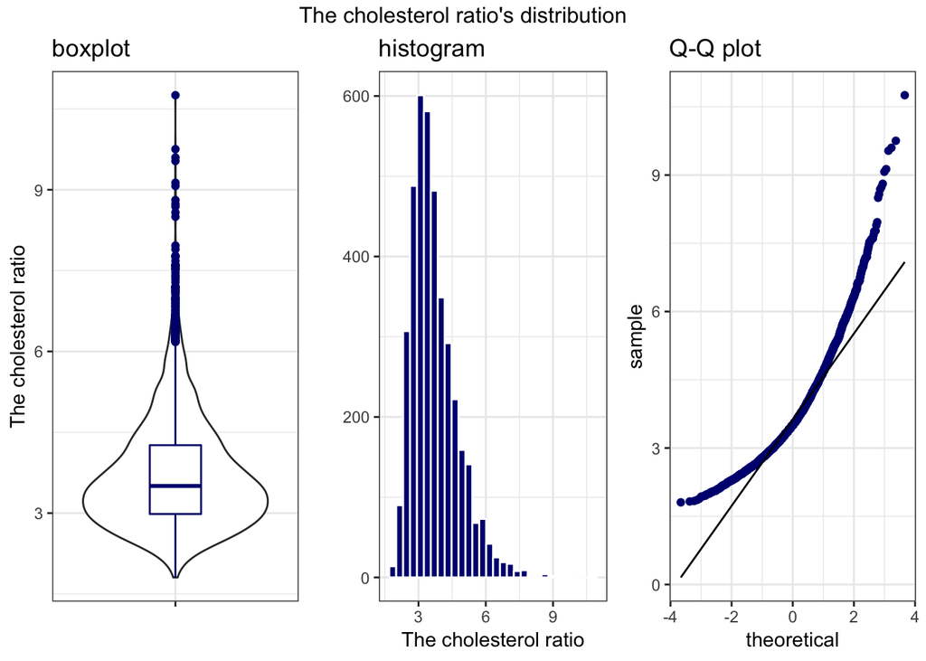

```r
viz1 <- ggplot(rc_training, aes(x = "", y = cho_ratio)) +
  geom_violin() +
  geom_boxplot(width = 0.25, col = "navy") +
  labs(title = "boxplot",
       x = "", y = "The cholesterol ratio") +
  theme_bw()

viz2 <- ggplot(rc_training, aes(x = cho_ratio)) +
  geom_histogram(bins = 30, col = "white", fill = "navy") +
  labs(title = "histogram",
       x = "The cholesterol ratio", y = "") +
  theme_bw()

viz3 <- ggplot(rc_training, aes(sample = cho_ratio)) +
  geom_qq(col = "navy") + geom_qq_line() +
   labs(title = "Q-Q plot") +
  theme_bw()

gridExtra::grid.arrange(viz1, viz2, viz3, nrow = 1,
                        top = "The cholesterol ratio's distribution")
```

## 7.2 Log transformation of outcome

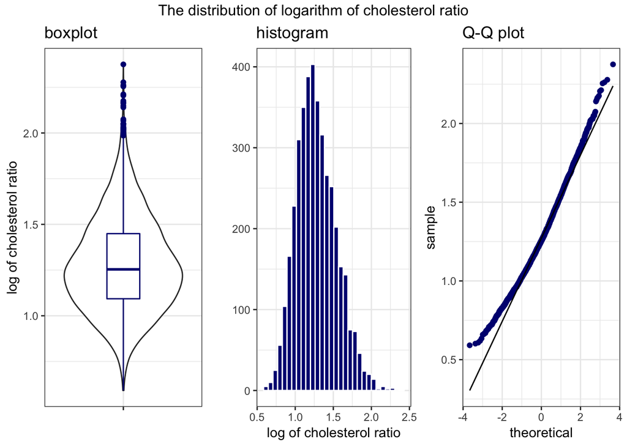

```r
viz4 <- ggplot(rc_training, aes(x = "", y = log(cho_ratio))) +
  geom_violin() +
  geom_boxplot(width = 0.25, col = "navy") +
  labs(title = "boxplot",
       x = "", y = "log of cholesterol ratio") +
  theme_bw()

viz5 <- ggplot(rc_training, aes(x = log(cho_ratio))) +
  geom_histogram(bins = 30, col = "white", fill = "navy") +
  labs(title = "histogram",
       x = "log of cholesterol ratio", y = "") +
  theme_bw()

viz6 <- ggplot(rc_training, aes(sample = log(cho_ratio))) +
  geom_qq(col = "navy") + geom_qq_line() +
   labs(title = "Q-Q plot") +
  theme_bw()

gridExtra::grid.arrange(viz4, viz5, viz6, nrow = 1,
                        top = "The distribution of logarithm of cholesterol ratio")
```

## 7.3 Numerical summary of the outcome and predictors

Here I make numerical summaries to look at the range of outcome after transformation, and the range of quantitative predictors, also look at the distribution of those two categorical variables. There is no missing value in each of the variable.

```r
mosaic::favstats(~ log(cho_ratio), data = rc_training)
```

```
       min       Q1   median       Q3     max     mean        sd    n
 0.5910979 1.093036 1.253798 1.449294 2.37538 1.279418 0.2596034 4000
 missing
       0
```

```r
rc_training %>% select(-sub_id, -cho_ratio) %>% Hmisc::describe()
```

```
.

 7  Variables      4000  Observations
---------------------------------------------------------------------------
id
       n  missing distinct     Info     Mean      Gmd      .05      .10
    4000        0     4000        1   345719   227869    34804    72322
     .25      .50      .75      .90      .95
  175720   343761   516937   621733   653714

lowest :    356    408    434    516    745, highest: 684501 684572 684768 685082 685286
---------------------------------------------------------------------------
bmi
       n  missing distinct     Info     Mean      Gmd      .05      .10
    4000        0      236        1    23.42    3.663     18.4     19.4
     .25      .50      .75      .90      .95
    21.1     23.3     25.6     27.6     29.0

lowest : 15.3 15.5 15.6 15.9 16.0, highest: 35.5 36.1 36.7 36.8 38.8
---------------------------------------------------------------------------
sbp
       n  missing distinct     Info     Mean      Gmd      .05      .10
    4000        0       93        1    118.2    16.21       96      100
     .25      .50      .75      .90      .95
     108      118      128      136      142

lowest :  78  82  83  84  85, highest: 172 175 178 184 185
---------------------------------------------------------------------------
dbp
       n  missing distinct     Info     Mean      Gmd      .05      .10
    4000        0       71    0.999    74.52    11.57       60       62
     .25      .50      .75      .90      .95
      67       74       81       88       92

lowest :  40  46  48  49  50, highest: 115 116 117 123 129
---------------------------------------------------------------------------
fpg2
       n  missing distinct     Info     Mean      Gmd      .05      .10
    4000        0      308    0.999    5.156   0.6028     4.40     4.51
     .25      .50      .75      .90      .95
    4.80     5.10     5.40     5.80     6.10

lowest :  3.40  3.50  3.80  3.90  3.92, highest:  9.42  9.47  9.69  9.90 10.70
---------------------------------------------------------------------------
smoke_sta
       n  missing distinct
    4000        0        3

Value      current    past   never
Frequency      807     187    3006
Proportion   0.202   0.047   0.752
---------------------------------------------------------------------------
drink_sta
       n  missing distinct
    4000        0        3

Value      current    past   never
Frequency      110     721    3169
Proportion   0.028   0.180   0.792
---------------------------------------------------------------------------
```

# 8 Step 4. Scatterplot Matrix

I build two scatter plot to look at the association between the log cho_ratio and predictors. There is no strong correlation between the outcome and quantitative predictors. The biggest correlation is between bmi and log_ratio, which is not considered to be strong (0.411).

From the second scatter plot matrix, we couldn’t have any clear conclusion about the association between the outcome and variables. So I make numerical summaries. So “current” group in both variables have higher mean and median of the “cho_ratio”, especially compare to the “never” group.

```r
rc_training <- rc_training %>%
  mutate(log_ratio = log(cho_ratio))
```

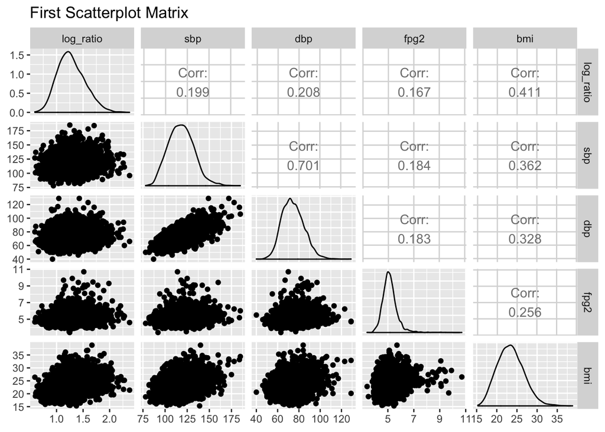

```r
rc_training  %>%
  select(log_ratio, sbp, dbp, fpg2, bmi) %>%
  ggpairs(., title = "First Scatterplot Matrix",
          lower = list(combo = wrap("facethist", bins = 20)))
```

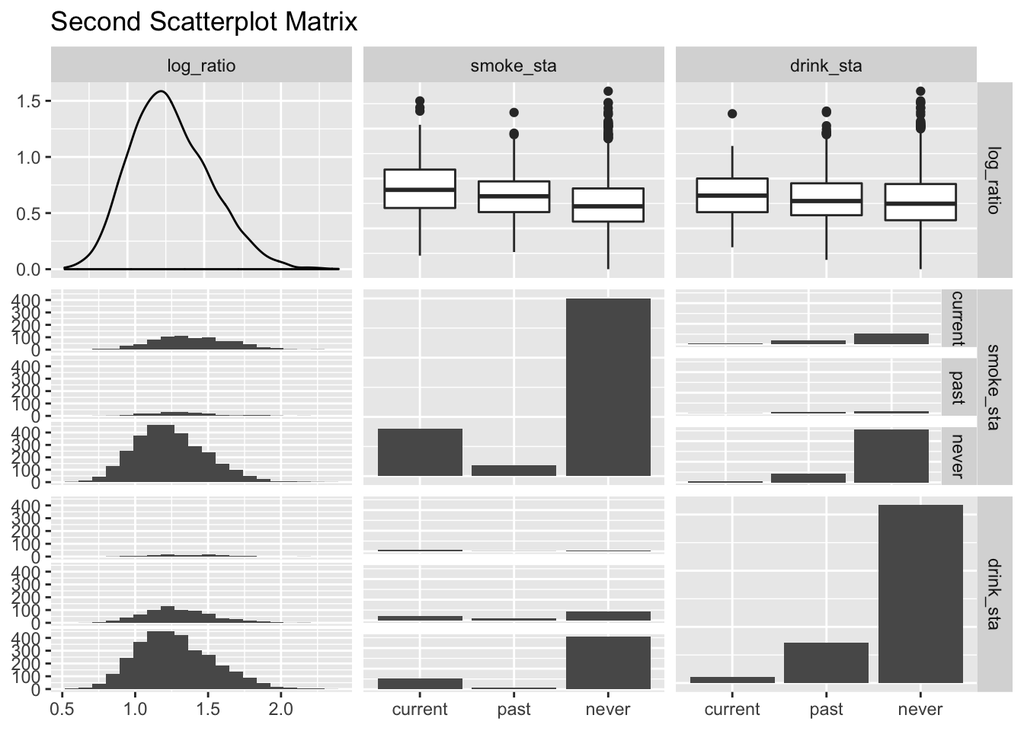

```r
rc_training %>%
  select(log_ratio, smoke_sta, drink_sta) %>%
  ggpairs(., title = "Second Scatterplot Matrix",
          lower = list(combo = wrap("facethist", bins = 20)))
```

```r
mosaic::favstats(log_ratio ~ smoke_sta, data = rc_training)
```

```
  smoke_sta       min       Q1   median       Q3      max     mean
1   current 0.7269446 1.204606 1.386294 1.589396 2.277662 1.398362
2      past 0.7628528 1.163524 1.321756 1.471151 2.161979 1.340183
3     never 0.5910979 1.068280 1.221166 1.400544 2.375380 1.243706
         sd    n missing
1 0.2632539  807       0
2 0.2557884  187       0
3 0.2484826 3006       0
```

```r
mosaic::favstats(log_ratio ~ drink_sta, data = rc_training)
```

```
  drink_sta       min       Q1   median       Q3      max     mean
1   current 0.8109302 1.162840 1.328448 1.500000 2.149400 1.339478
2      past 0.6845388 1.132108 1.274289 1.451892 2.175754 1.297254
3     never 0.5910979 1.082083 1.247611 1.444738 2.375380 1.273275
         sd    n missing
1 0.2450192  110       0
2 0.2422385  721       0
3 0.2635050 3169       0
```

## 8.1 Collinearity Checking

Since the correlation between ‘sbp’ and ‘dbp’ is 0.701, which is very strong correlation. So I decide to drop sbp in my further study.

# 9 Step 5. Kitchen Sink Model Assessment

## 9.1 The kitchen sink model

I make a linear regression model to describe the relationship between log cho_ratio and five predictors, `bmi`, `dbp`, `fpg2`, `smoke_sta`, and `drink_sta`.

```r
rc_ksink <- lm(log(cho_ratio) ~ bmi + dbp + fpg2 + smoke_sta + drink_sta,
                data = rc_training)

summary(rc_ksink)
```

```
Call:
lm(formula = log(cho_ratio) ~ bmi + dbp + fpg2 + smoke_sta +
    drink_sta, data = rc_training)

Residuals:
     Min       1Q   Median       3Q      Max
-0.75186 -0.16411 -0.01795  0.15122  1.19721

Coefficients:
                 Estimate Std. Error t value Pr(>|t|)
(Intercept)     0.4279243  0.0492403   8.691  < 2e-16 ***
bmi             0.0280750  0.0012404  22.633  < 2e-16 ***
dbp             0.0016268  0.0003783   4.301 1.74e-05 ***
fpg2            0.0233252  0.0064260   3.630 0.000287 ***
smoke_stapast  -0.0493626  0.0189060  -2.611 0.009063 **
smoke_stanever -0.1117139  0.0095406 -11.709  < 2e-16 ***
drink_stapast   0.0103350  0.0238561   0.433 0.664877
drink_stanever  0.0464883  0.0228692   2.033 0.042139 *
---
Signif. codes:  0 '***' 0.001 '**' 0.01 '*' 0.05 '.' 0.1 ' ' 1

Residual standard error: 0.2314 on 3992 degrees of freedom
Multiple R-squared:  0.2066,    Adjusted R-squared:  0.2053
F-statistic: 148.5 on 7 and 3992 DF,  p-value: < 2.2e-16
```

## 9.2 Summary of the model

From the model, we can conclude that：

```r
glance(rc_ksink)
```

```
# A tibble: 1 x 11
  r.squared adj.r.squared sigma statistic   p.value    df logLik   AIC
*     <dbl>         <dbl> <dbl>     <dbl>     <dbl> <int>  <dbl> <dbl>
1     0.207         0.205 0.231      149. 2.27e-195     8   182. -346.
# ... with 3 more variables: BIC <dbl>, deviance <dbl>, df.residual <int>
```

```r
augment(rc_ksink)
```

```
# A tibble: 4,000 x 13
   log.cho_ratio.   bmi   dbp  fpg2 smoke_sta drink_sta .fitted .se.fit
 *          <dbl> <dbl> <int> <dbl> <fct>     <fct>       <dbl>   <dbl>
 1          1.30   20.4    69  5    never     never        1.16 0.00536
 2          1.56   22.1    71  5    never     never        1.22 0.00462
 3          0.993  17.7    69  4.63 never     never        1.08 0.00767
 4          0.953  19.4    65  5.11 never     never        1.13 0.00641
 5          1.01   20.2    71  5.12 never     never        1.16 0.00549
 6          0.857  21.1    64  4.65 never     never        1.17 0.00612
 7          0.884  19.4    51  5.36 never     never        1.12 0.00992
 8          1.21   22.6    70  5.42 never     never        1.24 0.00510
 9          1.31   23.8    95  5.28 current   never        1.42 0.0113
10          1.37   26.6    83  5.54 past      never        1.44 0.0180
# ... with 3,990 more rows, and 5 more variables: .resid <dbl>,
#   .hat <dbl>, .sigma <dbl>, .cooksd <dbl>, .std.resid <dbl>
```

## 9.3 Interpret coffiencient estimates

The equation of our model is : log(cho_ratio) = (0.42 + 0.03 bmi + 0.002 dbp + 0.02 fpg2 - 0.05 (if past smoker) or - 0.1 (if never smoker) + 0.01 (if past drinker) or + 0.05 (if never drinker))

For other predictors:

1. An increase of 1 mm Hg in dbp is associated with a significant increase of 0.002 (90% confidence interval:0.0010, 0.0022) in log cho_ratio.
2. An increase of 1 mmol/L in fpg2 is associated with a significant increase of 0.02 (90% confidence interval:0.013, 0.034) in log cho_ratio.
3. People who are past smoker will have an significant decrease of 0.05 (90% confidence interval:-0.08, -0.01) in log cho_ratio compared to current smoker.People who never smoke will have an significant decrease of 0.1 (90% confidence interval:-0.12, -0.09) in log cho_ratio compared to current smoker.
4. People who are past drinker will have an non-significant increase of 0.01 (90% confidence interval:-0.03, 0.05) in log cho_ratio compared to current drinker.People who never drink will have an significant increase of 0.05 (90% confidence interval:0.009, 0.084) in log cho_ratio compared to current drinker.

```r
tidy(rc_ksink, conf.int = TRUE, conf.level = 0.9)
```

```
# A tibble: 8 x 7
  term           estimate std.error statistic   p.value conf.low conf.high
  <chr>             <dbl>     <dbl>     <dbl>     <dbl>    <dbl>     <dbl>
1 (Intercept)     0.428    0.0492       8.69  5.18e- 18  0.347     0.509
2 bmi             0.0281   0.00124     22.6   8.27e-107  0.0260    0.0301
3 dbp             0.00163  0.000378     4.30  1.74e-  5  0.00100   0.00225
4 fpg2            0.0233   0.00643      3.63  2.87e-  4  0.0128    0.0339
5 smoke_stapast  -0.0494   0.0189      -2.61  9.06e-  3 -0.0805   -0.0183
6 smoke_stanever -0.112    0.00954    -11.7   3.67e- 31 -0.127    -0.0960
7 drink_stapast   0.0103   0.0239       0.433 6.65e-  1 -0.0289    0.0496
8 drink_stanever  0.0465   0.0229       2.03  4.21e-  2  0.00886   0.0841
```

## 9.4 Check collinearity

The generalized variance inflation factor values are all below 5, so we are fine.

```r
car::vif(rc_ksink)
```

```
              GVIF Df GVIF^(1/(2*Df))
bmi       1.217948  1        1.103607
dbp       1.141223  1        1.068281
fpg2      1.085065  1        1.041665
smoke_sta 1.116896  2        1.028024
drink_sta 1.100430  2        1.024214
```

# 10 Step 6. Build a smaller linear model

## 10.1 Backards stepwise elimination

Since the stepwise approach doesn’t drop any of the variables, so I select two of the varietals that have biggest RSS value, which is bmi and smoke_sta.

```r
step(rc_ksink)
```

```
Start:  AIC=-11699.74
log(cho_ratio) ~ bmi + dbp + fpg2 + smoke_sta + drink_sta

            Df Sum of Sq    RSS    AIC
<none>                   213.82 -11700
- fpg2       1    0.7057 214.52 -11689
- drink_sta  2    0.8612 214.68 -11688
- dbp        1    0.9907 214.81 -11683
- smoke_sta  2    7.5089 221.32 -11566
- bmi        1   27.4368 241.25 -11219
```

```
Call:
lm(formula = log(cho_ratio) ~ bmi + dbp + fpg2 + smoke_sta +
    drink_sta, data = rc_training)

Coefficients:
   (Intercept)             bmi             dbp            fpg2
      0.427924        0.028075        0.001627        0.023325
 smoke_stapast  smoke_stanever   drink_stapast  drink_stanever
     -0.049363       -0.111714        0.010335        0.046488
```

## 10.2 A new smaller model

Here I build a new smaller model, with these two variables, ‘bmi’ and ‘smoke_sta’. From this smaller model, we can conclude that:

1. This model accounts for 19.60% variation in the log of cho_ratio. The adjusted r square is similar to multiple r squared, so there is no problem with collinearity.
2. The residual standard error is 0.23, so 95% of the prediction errors should be between -0.46 and 0.46, and all residuals should be between -0.69 and 0.69.
3. The F test p value is very small, indicate that there is significant amour of predictive value can be accounted for the model.

```r
rc_small <- lm(log(cho_ratio) ~ bmi +  smoke_sta, data = rc_training)
tidy(rc_small, conf.int = TRUE, conf.level = 0.9)
```

```
# A tibble: 4 x 7
  term           estimate std.error statistic   p.value conf.low conf.high
  <chr>             <dbl>     <dbl>     <dbl>     <dbl>    <dbl>     <dbl>
1 (Intercept)      0.658    0.0295      22.3  4.84e-104   0.609     0.706
2 bmi              0.0302   0.00115     26.1  2.85e-139   0.0283    0.0321
3 smoke_stapast   -0.0582   0.0189      -3.08 2.09e-  3  -0.0893   -0.0271
4 smoke_stanever  -0.109    0.00939    -11.7  6.94e- 31  -0.125    -0.0940
```

```r
glance(rc_small)
```

```
# A tibble: 1 x 11
  r.squared adj.r.squared sigma statistic   p.value    df logLik   AIC
*     <dbl>         <dbl> <dbl>     <dbl>     <dbl> <int>  <dbl> <dbl>
1     0.197         0.196 0.233      326. 2.41e-189     4   157. -304.
# ... with 3 more variables: BIC <dbl>, deviance <dbl>, df.residual <int>
```

# 11 Step 7. Compare the kitchen sink model and the new samller model in the training sample

## 11.1 Setting up out of sample validation

The kitchen sink model has smaller AIC and BIC, larger r.squared and adj.r.squared, smaller error. So the kitchen sink model is more preferable than the smaller model.

```r
temp_1 <- glance(rc_ksink) %>%
  select(-logLik, -deviance) %>%
  round(digits = 3) %>%
  mutate(modelname = "kitchen sink model")

temp_2 <- glance(rc_small) %>%
  select(-logLik, -deviance) %>%
  round(digits = 3) %>%
  mutate(modelname = "smaller model")

training_comp <- bind_rows(temp_1, temp_2) %>%
  select(modelname, df, AIC, BIC, everything())

training_comp
```

```
# A tibble: 2 x 10
  modelname    df   AIC   BIC r.squared adj.r.squared sigma statistic
  <chr>     <dbl> <dbl> <dbl>     <dbl>         <dbl> <dbl>     <dbl>
1 kitchen …     8 -346. -290.     0.207         0.205 0.231      149.
2 smaller …     4 -304. -273.     0.197         0.196 0.233      326.
# ... with 2 more variables: p.value <dbl>, df.residual <dbl>
```

# 12 Step 8. Use the Two Models to predict the outcome in the Test Sample

## 12.1 Prediction errors

Here I calculate prediction errors we observe in the test sample.

```r
test_ksink <- augment(rc_ksink, newdata = rc_test) %>%
  mutate(modelname = "kitchen sink model",
         .resid = cho_ratio -exp(.fitted),
         .expfit = exp(.fitted))%>%
  select(sub_id, modelname, cho_ratio, .fitted, .resid,
         bmi, dbp, fpg2, smoke_sta, drink_sta,
         everything())

test_small <- augment(rc_small, newdata = rc_test) %>%
  mutate(modelname = "samller model",
         .resid = cho_ratio - exp(.fitted),
         .expfit = exp(.fitted)) %>%
  select(sub_id, modelname, cho_ratio, .fitted, .resid,
        bmi, smoke_sta,
         everything())

test_both <- union(test_ksink, test_small) %>%
  arrange(sub_id, modelname)

test_both
```

```
# A tibble: 4,000 x 14
   sub_id modelname cho_ratio .fitted  .resid   bmi   dbp  fpg2 smoke_sta
   <chr>  <chr>         <dbl>   <dbl>   <dbl> <dbl> <int> <dbl> <fct>
 1 100028 kitchen …      3.33    1.36 -0.560   27      72  5.2  never
 2 100028 samller …      3.33    1.36 -0.574   27      72  5.2  never
 3 100059 kitchen …      3.44    1.23  0.0121  20.7    61  4.89 current
 4 100059 samller …      3.44    1.28 -0.162   20.7    61  4.89 current
 5 100104 kitchen …      4.71    1.31  1.000   24.1    89  5.4  never
 6 100104 samller …      4.71    1.28  1.13    24.1    89  5.4  never
 7 100186 kitchen …      3.03    1.13 -0.0609  19.6    62  4.98 never
 8 100186 samller …      3.03    1.14 -0.0910  19.6    62  4.98 never
 9 100229 kitchen …      5.02    1.49  0.567   27.7    68  7.21 current
10 100229 samller …      5.02    1.49  0.573   27.7    68  7.21 current
# ... with 3,990 more rows, and 5 more variables: drink_sta <fct>,
#   id <int>, sbp <int>, .se.fit <dbl>, .expfit <dbl>
```

## 12.2 Visulaize the prediction errors

I couldn’t observe any difference of prediction errors between the two models.

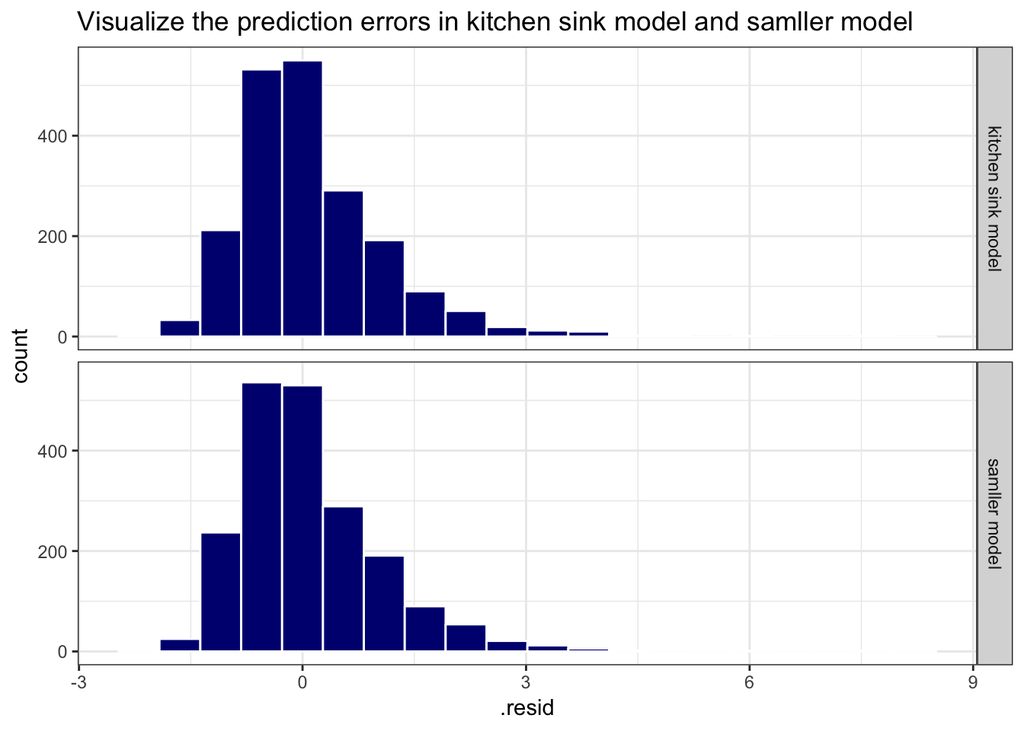

```r
ggplot(test_both, aes(x = .resid)) +
  geom_histogram(bins = 20, col = "white", fill = "navy") +
  facet_grid (modelname ~ .) +
  labs(title = "Visualize the prediction errors in kitchen sink model and samller model") +
  theme_bw()
```

## 12.3 Comparing the prediction errors

The kitchen sink model has smaller MAPE, MSPE, and maxim error, so this model is slightly better than the smaller model.

```r
test_both %>%
  group_by(modelname) %>%
  summarise(n = n(),
            MAPE = mean(abs(.resid)),
            MSPE = mean(.resid^2),
            max_error = max(abs(.resid)))
```

```
# A tibble: 2 x 5
  modelname              n  MAPE  MSPE max_error
  <chr>              <int> <dbl> <dbl>     <dbl>
1 kitchen sink model  2000 0.703 0.948      7.91
2 samller model       2000 0.709 0.958      7.99
```

## 12.4 Identify the largest errors

```r
temp1 <- test_ksink %>%
  filter(abs(.resid) == max(abs(.resid)))

temp2 <- test_small %>%
  filter(abs(.resid) == max(abs(.resid)))

bind_rows(temp1, temp2)
```

```
# A tibble: 2 x 14
  sub_id modelname cho_ratio .fitted .resid   bmi   dbp  fpg2 smoke_sta
  <chr>  <chr>         <dbl>   <dbl>  <dbl> <dbl> <int> <dbl> <fct>
1 97686  kitchen …      11.2    1.18   7.91    20    79   5.4 never
2 97686  samller …      11.2    1.15   7.99    20    79   5.4 never
# ... with 5 more variables: drink_sta <fct>, id <int>, sbp <int>,
#   .se.fit <dbl>, .expfit <dbl>
```

# 13 Step 9. Apply The Better Model To The Whole Data Set

## 13.1 Apply the better model to the whole data set

I chose the kitchen sink model with five predictors, and apply it to the whole data set.

```r
final_mod <- lm(log(cho_ratio) ~ bmi + dbp + fpg2 + smoke_sta + drink_sta, data = RCfinal)

tidy(final_mod, conf.int = TRUE, conf.level = 0.9)
```

```
# A tibble: 8 x 7
  term           estimate std.error statistic   p.value conf.low conf.high
  <chr>             <dbl>     <dbl>     <dbl>     <dbl>    <dbl>     <dbl>
1 (Intercept)     0.418    0.0185       22.7  1.02e-112  0.388     0.449
2 bmi             0.0277   0.000455     60.9  0.         0.0270    0.0285
3 dbp             0.00200  0.000143     14.0  1.70e- 44  0.00176   0.00223
4 fpg2            0.0197   0.00233       8.44 3.30e- 17  0.0159    0.0235
5 smoke_stapast  -0.0476   0.00747      -6.36 1.99e- 10 -0.0599   -0.0353
6 smoke_stanever -0.0996   0.00364     -27.4  4.80e-163 -0.106    -0.0936
7 drink_stapast   0.0139   0.00926       1.50 1.33e-  1 -0.00132   0.0291
8 drink_stanever  0.0337   0.00890       3.78 1.55e-  4  0.0190    0.0483
```

## 13.2 Check assumption violations

The four plots all look normal to me, except there is one outlier, point 2403. Even though this outlier doesn’t affect the overall assumption, I still decide to have a look at this point. Then I find that this single outlier has the smallest log cho_ratio.

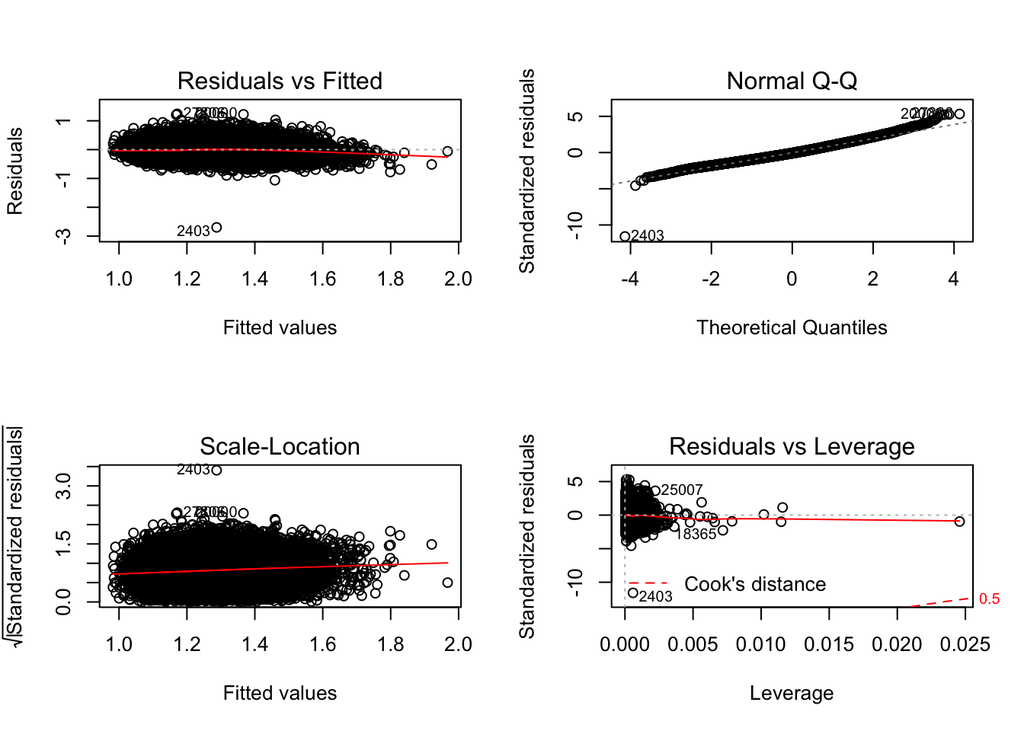

```r
par(mfrow=c(2,2))
plot(final_mod)
```

```r
par(mfrow=c(1,1))
```

```r
final_aug <- augment(final_mod) %>%
bind_cols(RCfinal %>% select(id)) %>%
select(id, everything())
slice(final_aug, c(2403)) %>% print.data.frame(digits=3)
```

```
     id log.cho_ratio.  bmi dbp fpg2 smoke_sta drink_sta .fitted .se.fit
1 58486          -1.41 23.1  74 7.43     never     never    1.29 0.00566
  .resid     .hat .sigma .cooksd .std.resid
1   -2.7 0.000591  0.232 0.00993      -11.6
```

```r
mosaic::favstats(~ log(cho_ratio), data = RCfinal)
```

```
       min       Q1   median       Q3      max     mean        sd     n
 -1.409642 1.086549 1.245745 1.434102 2.590267 1.269025 0.2605179 28522
 missing
       0
```

## 13.3 Subject 58486

Here the subject id refer to the original id in the raw data.

Subject 58486 has a cholesterol of 2.54 mmol/L, HDL of 10.4 mmol/L. The normal range of HDL is from 1.04 mmol/L to 2.45 mmol/L, 10.4 is extremely high. It would be reasonable to exclude this subject in the final model.

## 13.4 Run the model without subject 58486

I remove the subject 58486, now the plots look completely normal.

```r
final_mod2 <- RCfinal %>% filter(id != "58486") %$%
lm(log(cho_ratio) ~ bmi + dbp + fpg2 + smoke_sta + drink_sta)
tidy(final_mod2, conf.int = TRUE, conf.level = 0.9)
```

```
# A tibble: 8 x 7
  term           estimate std.error statistic   p.value conf.low conf.high
  <chr>             <dbl>     <dbl>     <dbl>     <dbl>    <dbl>     <dbl>
1 (Intercept)     0.416    0.0184       22.6  7.55e-112  0.386     0.446
2 bmi             0.0277   0.000454     61.0  0.         0.0270    0.0285
3 dbp             0.00200  0.000142     14.0  1.54e- 44  0.00176   0.00223
4 fpg2            0.0203   0.00233       8.73 2.73e- 18  0.0165    0.0242
5 smoke_stapast  -0.0475   0.00746      -6.38 1.85e- 10 -0.0598   -0.0353
6 smoke_stanever -0.0994   0.00363     -27.4  2.77e-163 -0.105    -0.0934
7 drink_stapast   0.0139   0.00924       1.51 1.32e-  1 -0.00127   0.0291
8 drink_stanever  0.0338   0.00888       3.80 1.43e-  4  0.0192    0.0484
```

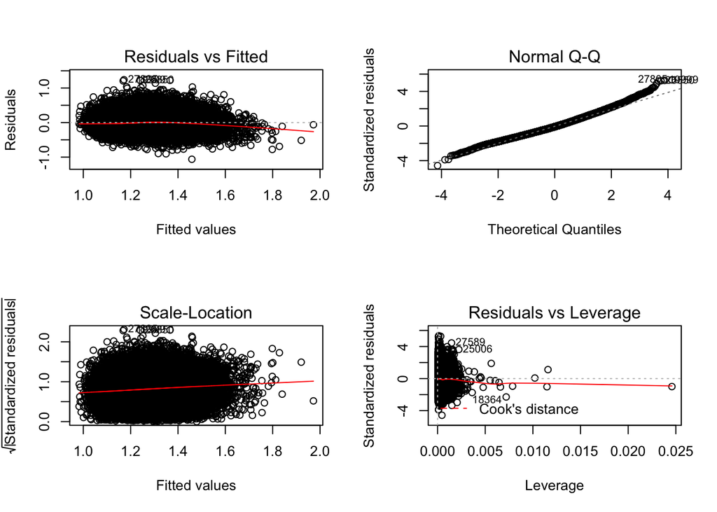

```r
par(mfrow=c(2,2))
plot(final_mod2)
```

```r
par(mfrow=c(1,1))
```

## 13.5 Interpret the final model

The equation of this model should be:

cho_ratio = exp(0.42 + 0.0277 bmi + 0.002 dbp + 0.02 fpg2 -0.04 (if past smoker) or - 0.1 (if never smoker) +0.014 (if past drinker) or +0.034 (if never drinker))

For other predictors:

1. An increase of 1 mm Hg in dbp is associated with a significant increase of 0.002 (90% confidence interval:0.0018, 0.0022) in log cho_ratio.
2. An increase of 1 mmol/L in fpg2 is associated with a significant increase of 0.02 (90% confidence interval:0.016, 0.024) in log cho_ratio.
3. People who are past smoker will have an significant decrease of 0.04 (90% confidence interval:-0.060, -0.035) in log cho_ratio compared to current smoker.People who never smoke will have an significant decrease of 0.1 (90% confidence interval:-0.10, -0.09) in log cho_ratio compared to current smoker.
4. People who are past drinker will have an non-significant increase of 0.014 (90% confidence interval:-0.001, 0.029) in log cho_ratio compared to current drinker.People who never drink will have an significant increase of 0.034 (90% confidence interval:0.019, 0.048) in log cho_ratio compared to current drinker.

```r
summary(final_mod2)
```

```
Call:
lm(formula = log(cho_ratio) ~ bmi + dbp + fpg2 + smoke_sta +
    drink_sta)

Residuals:
    Min      1Q  Median      3Q     Max
-1.0622 -0.1609 -0.0181  0.1460  1.2401

Coefficients:
                 Estimate Std. Error t value Pr(>|t|)
(Intercept)     0.4158390  0.0184215  22.574  < 2e-16 ***
bmi             0.0277140  0.0004542  61.014  < 2e-16 ***
dbp             0.0019952  0.0001423  14.025  < 2e-16 ***
fpg2            0.0203205  0.0023281   8.728  < 2e-16 ***
smoke_stapast  -0.0475376  0.0074566  -6.375 1.85e-10 ***
smoke_stanever -0.0994123  0.0036269 -27.410  < 2e-16 ***
drink_stapast   0.0139176  0.0092359   1.507 0.131847
drink_stanever  0.0337847  0.0088818   3.804 0.000143 ***
---
Signif. codes:  0 '***' 0.001 '**' 0.01 '*' 0.05 '.' 0.1 ' ' 1

Residual standard error: 0.2323 on 28513 degrees of freedom
Multiple R-squared:  0.2024,    Adjusted R-squared:  0.2022
F-statistic:  1034 on 7 and 28513 DF,  p-value: < 2.2e-16
```

```r
tidy(final_mod2, conf.int = TRUE, conf.level = 0.9)
```

```
# A tibble: 8 x 7
  term           estimate std.error statistic   p.value conf.low conf.high
  <chr>             <dbl>     <dbl>     <dbl>     <dbl>    <dbl>     <dbl>
1 (Intercept)     0.416    0.0184       22.6  7.55e-112  0.386     0.446
2 bmi             0.0277   0.000454     61.0  0.         0.0270    0.0285
3 dbp             0.00200  0.000142     14.0  1.54e- 44  0.00176   0.00223
4 fpg2            0.0203   0.00233       8.73 2.73e- 18  0.0165    0.0242
5 smoke_stapast  -0.0475   0.00746      -6.38 1.85e- 10 -0.0598   -0.0353
6 smoke_stanever -0.0994   0.00363     -27.4  2.77e-163 -0.105    -0.0934
7 drink_stapast   0.0139   0.00924       1.51 1.32e-  1 -0.00127   0.0291
8 drink_stanever  0.0338   0.00888       3.80 1.43e-  4  0.0192    0.0484
```

# 14 The Association Between Bmi and Cho_ratio

In this part, I will separate bmi into four groups: underweight, normal, overweight, obese. In my hypotheses, obese is closely related with high cholesterol ratio.

```r
mosaic::favstats(~ bmi, data = RCfinal)
```

```
 min Q1 median   Q3 max     mean       sd     n missing
  15 21   23.2 25.5  44 23.41608 3.317688 28522       0
```

```r
RCfinal$bmicat<-cut(RCfinal$bmi, c(-Inf, 18.5, 25 ,30, 44),
                    labels=c("Underweight", "Normal", "Overweight", "Obese" ))
```

## 14.1 Numerical summary

“Obese” and “Overweight” group has highest mean and median of cho_ratio.

```r
mosaic::favstats(cho_ratio ~ bmicat, data = RCfinal)
```

```
       bmicat       min       Q1   median       Q3      max     mean
1 Underweight 1.7942857 2.553878 2.867785 3.306091  6.87013 2.992234
2      Normal 0.2442308 2.884326 3.336283 3.972850 13.33333 3.517211
3  Overweight 1.4864865 3.356757 3.928571 4.779070 12.08108 4.152245
4       Obese 2.1850000 3.548462 4.242306 5.098171 11.03571 4.435851
         sd     n missing
1 0.6428810  1540       0
2 0.9223999 18599       0
3 1.1107286  7469       0
4 1.1755230   914       0
```

## 14.2 Graphical summary of `cho_ratio`

The distribution of outcome ‘cho_ratio’ is right skewed based on box plot and Q-Q plot.

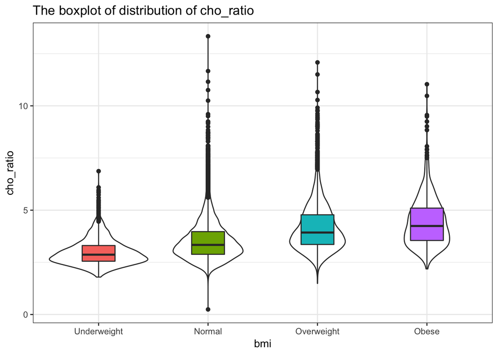

```r
ggplot(RCfinal, aes(x = bmicat, y = cho_ratio)) +
  geom_violin(fill = "white") +
  geom_boxplot(aes(fill = bmicat), width = 0.3, notch = FALSE) +
  guides(fill = FALSE, col = FALSE) +
  labs(title = "The boxplot of distribution of cho_ratio",
       x = "bmi",
       y = "cho_ratio") +
  theme_bw()
```

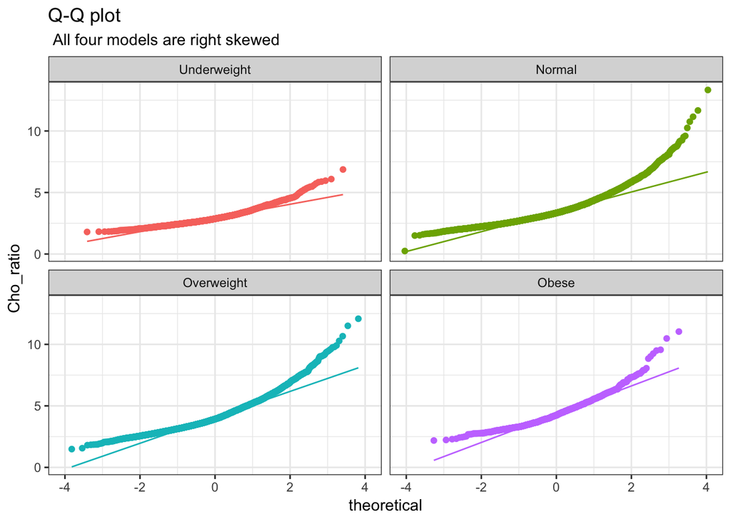

```r
ggplot(RCfinal, aes(sample = cho_ratio, col = bmicat)) +
  geom_qq() + geom_qq_line() +
  facet_wrap(~ bmicat) +
  guides(col = FALSE) +
  theme_bw() +
  labs(y = "Cho_ratio",
       title = "Q-Q plot",
       subtitle = " All four models are right skewed")
```

## 14.3 Graphical summary of log `cho_ratio`

I make a log transformation of ‘cho_ratio’, now the distribution is normal.

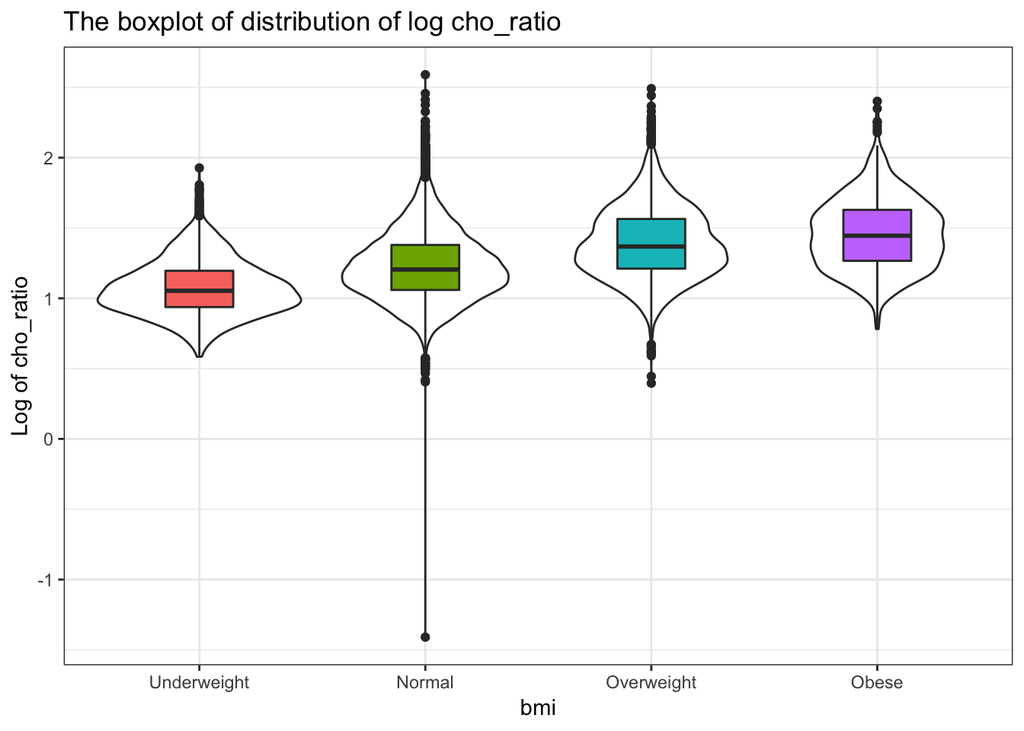

```r
ggplot(RCfinal, aes(x = bmicat, y = log(cho_ratio))) +
  geom_violin(fill = "white") +
  geom_boxplot(aes(fill = bmicat), width = 0.3, notch = FALSE) +
  guides(fill = FALSE, col = FALSE) +
  labs(title = "The boxplot of distribution of log cho_ratio",
       x = "bmi",
       y = "Log of cho_ratio") +
  theme_bw()
```

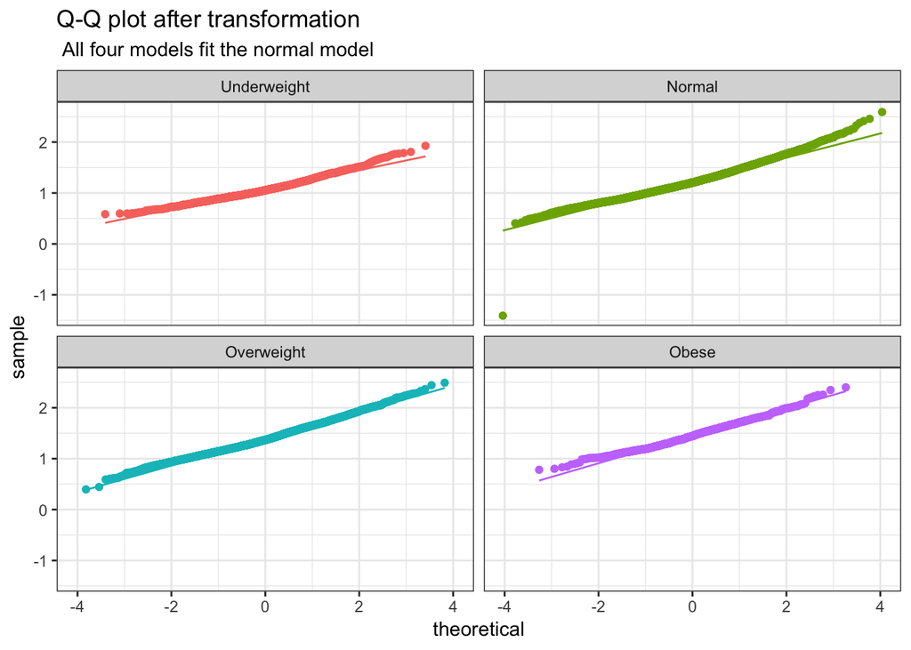

```r
ggplot(RCfinal, aes(sample = log(cho_ratio), col = bmicat)) +
  geom_qq() + geom_qq_line() +
  facet_wrap(~ bmicat) +
  guides(col = FALSE) +
  theme_bw() +
  labs(title = "Q-Q plot after transformation",
       subtitle = " All four models fit the normal model")
```

## 14.4 Analysis of Variance

Like previously mentioned, I exclude subject with id 58486, because of strange value of predictor. The p value is really small, so there is significant difference between the mean of log cho_ratio for the four groups. And ‘bmi’ account for 12% of the variance of log cho_ratio.

```r
RCfinal <- RCfinal %>%
  mutate(log_cho = log(cho_ratio))
bmi_mod <- RCfinal %>% filter(id != "58486") %$%
  lm(log_cho ~ bmicat)
anova(bmi_mod)
```

```
Analysis of Variance Table

Response: log_cho
             Df  Sum Sq Mean Sq F value    Pr(>F)
bmicat        3  233.98  77.994  1312.5 < 2.2e-16 ***
Residuals 28517 1694.55   0.059
---
Signif. codes:  0 '***' 0.001 '**' 0.01 '*' 0.05 '.' 0.1 ' ' 1
```

## 14.5 Tukey’s Honestly Significant Differences approach

I would like to test the difference between each two groups. All the p values are close to 0, which indicates that the log cho_ratio is significantly different between each two groups.

```r
TukeyHSD(aov(RCfinal$log_cho ~ RCfinal$bmicat), conf.level = 0.90)
```

```
  Tukey multiple comparisons of means
    90% family-wise confidence level

Fit: aov(formula = RCfinal$log_cho ~ RCfinal$bmicat)

$`RCfinal$bmicat`
                             diff        lwr        upr p adj
Normal-Underweight     0.15181821 0.13697730 0.16665911     0
Overweight-Underweight 0.31574622 0.30008256 0.33140988     0
Obese-Underweight      0.38241464 0.35904509 0.40578419     0
Overweight-Normal      0.16392801 0.15626103 0.17159499     0
Obese-Normal           0.23059643 0.21163415 0.24955872     0
Obese-Overweight       0.06666842 0.04705551 0.08628133     0
```